# Reviewer of product comments in Portuguese

## Strategie 2

```python
from sklearn.feature_extraction.text import CountVectorizer

# instantiate the vectorizer
vect = CountVectorizer()
vect.fit(np.concatenate((x_train, x_test), axis=0))

X_train_dtm = vect.transform(x_train)
X_test_dtm = vect.transform(x_test)
x_full_dtm = vect.transform( np.concatenate((x_train, x_test), axis=0) )

from sklearn.feature_extraction.text import TfidfTransformer

tfidf_transformer = TfidfTransformer()
tfidf_transformer.fit( x_full_dtm )
X_train_dtm_tfft = tfidf_transformer.transform(X_train_dtm)
X_test_dtm_tfft  = tfidf_transformer.transform(X_test_dtm)
```

```python
from sklearn.svm import LinearSVC

linear_svc = LinearSVC(C=0.5, random_state=42)
linear_svc.fit(X_train_dtm, y_train)
y_pred_class = linear_svc.predict(X_test_dtm)
class_report(y_test, y_pred_class, "Strategie 1: Keras NN CountVectorizer") # 0.89, 0.88

linear_svc = LinearSVC(C=0.5, random_state=42)
linear_svc.fit(X_train_dtm_tfft, y_train)
y_pred_class = linear_svc.predict(X_test_dtm_tfft)
class_report(y_test, y_pred_class, "Strategie 1: Keras NN TD-IDF") # 0.90, 0.89
```

[output not shown]

```python
from sklearn.linear_model import LogisticRegression

logreg = LogisticRegression(solver='liblinear')
logreg.fit(X_train_dtm, y_train)
y_pred_class = logreg.predict(X_test_dtm)
class_report(y_test, y_pred_class, "Strategie 2: Keras NN TD-IDF")

logreg = LogisticRegression(solver='liblinear')
logreg.fit(X_train_dtm_tfft, y_train)
y_pred_class = logreg.predict(X_test_dtm_tfft)
class_report(y_test, y_pred_class, "Strategie 2: Keras NN TD-IDF")
```

[output not shown]

```python
from sklearn.ensemble import RandomForestClassifier

forest = RandomForestClassifier()
forest = forest.fit(X_train_dtm, y_train)
y_pred = forest.predict(X_test_dtm)

class_report(y_test, y_pred, 'Strategie 2: RandomForestClassifier VetCount:')
```

```
Strategie 2: RandomForestClassifier VetCount:

[[2637  414]
 [ 488 4812]]

              precision    recall  f1-score   support

    Negative       0.84      0.86      0.85      3051
    Positive       0.92      0.91      0.91      5300

    accuracy                           0.89      8351
   macro avg       0.88      0.89      0.88      8351
weighted avg       0.89      0.89      0.89      8351
```

```python
# plt.figure(figsize = (12,5)) # fom imbd-popcorn my kernel
# feat_importances = pd.Series(forest.feature_importances_)#, index=X.columns)
# feat_importances.nlargest(30).reset_index().replace(inv_map).set_index('index').plot(kind='barh', use_index=True)
# plt.show()

int_top = 30
inv_map = {v: k for k, v in vect.vocabulary_.items()}
feat_importances = pd.Series(forest.feature_importances_)
labels_top = [ inv_map[el] for el in feat_importances.nlargest(int_top).index.tolist()]
```

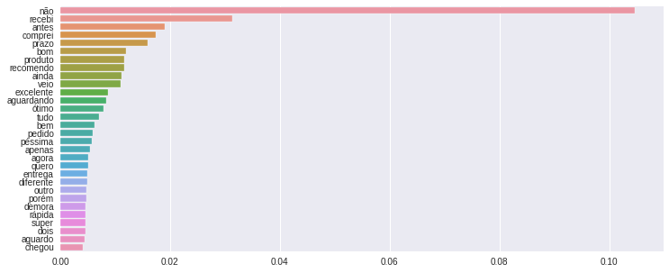

```python
plt.figure(figsize = (12,5))
sns.barplot(y=labels_top, x=feat_importances.nlargest(int_top))
plt.show()
```

================================

## Vectorizer PyTorch

```python
pause_here
```

[output not shown]

```python
from collections import Counter

## Constroi um dict que mapeia palavras para inteiros
counts = Counter(df['clean_comment'])
vocab = sorted(counts, key=counts.get, reverse=True)
vocab_to_int = {word: ii for ii, word in enumerate(vocab, 1)}

## Usa o dict para ccodificar cada comentario em reviews_split
## Armazenar os comentários em reviews_ints
reviews_ints = []
for review in reviews_split:
    reviews_ints.append([vocab_to_int[word] for word in review.split()])
```

```python
print('Palavras unicas: ', len((vocab_to_int)), '\n')

#imprime primeiro comentario codificado
print('Comentário codificado: \n', reviews_ints[:2])
```

[output not shown]

```python
encoded_labels = [1 if c>3 else 0 for c in df['score']]
plt.hist(encoded_labels); # Qtd de positivos (1) e negativos (0) depois de mapear {1,2,3} => Zero| Negativo, resto Um|Positivo
```

```python
# Comentarios
review_lens = Counter([len(x) for x in reviews_ints])
print("Comentários de tamanho zero: {}".format(review_lens[0]))
print("Tamanho máximo de um comentário: {}".format( max(review_lens)))
# Comentários de tamanho zero: 132
# Tamanho máximo de um comentário: 45
## Remove quaisquer comentários / etiquetas com comprimento zero da lista reviews_ints.
```

[output not shown]

```python
# Obtem indices de comentarios com comprimento difrente de zero
non_zero_idx = [ii for ii, review in enumerate(reviews_ints) if len(review) != 0]

# Remove comntarios de tamanho zero
reviews_ints = [reviews_ints[ii] for ii in non_zero_idx]
encoded_labels = np.array([encoded_labels[ii] for ii in non_zero_idx])
reviews_ints = reviews_ints[:41500]
encoded_labels = encoded_labels[:41500]
```

==========================================================

## Pré-processamento de dados

Codifica cada palavra como um numero inteiro e remove toda a pontuação.

```python
# punctuation é uma lista de strings de pontuação {'.', ',', ';', '!' ...}
from string import punctuation

# Remove pontuação e outros caracteres
reviews_split= []
for review in reviews:
    reviews_split.append(''.join([c for c in review if c not in punctuation]).replace('\r\n',' '))

all_text = ' '.join(reviews_split)

# Cria uma lista com as palavras
words = all_text.split()
```

```python
words[:30]
```

```python
reviews_split[:5]
```

```python
dfe = pd.read_pickle('vocab_to_int')
```

```python
dfe['o']
```

### Codifica as palavras

Cria um dicionário que mapeia as palavras no vocabulário para números inteiros.Em seguida, converte-se cada um dos comentarios em números inteiros para que possam ser passados para a rede.

```python
from collections import Counter

## Constroi um dict que mapeia palavras para inteiros
counts = Counter(words)
vocab = sorted(counts, key=counts.get, reverse=True)
vocab_to_int = {word: ii for ii, word in enumerate(vocab, 1)}

## Usa o dict para ccodificar cada comentario em reviews_split
## Armazenar os comentários em reviews_ints
reviews_ints = []
for review in reviews_split:
    reviews_ints.append([vocab_to_int[word] for word in review.split()])
```

```python
print('Palavras unicas: ', len((vocab_to_int)), '\n')

#imprime primeiro comentario codificado
print('Comentário codificado: \n', reviews_ints[:1])
```

[output not shown]

```python
# Mapeamento de palavras em números
vocab_to_string = { ii: word for word, ii  in vocab_to_int.items()}
print(vocab_to_string)
```

### Codifica as avaliações

```python
encoded_labels = [1 if c>3 else 0 for c in labels]
```

```python
plt.hist(encoded_labels); # Qtd de positivos (1) e negativos (0) depois de mapear {1,2,3} => Zero| Negativo, resto Um|Positivo
```

```python
# Comentarios
review_lens = Counter([len(x) for x in reviews_ints])
print("Comentários de tamanho zero: {}".format(review_lens[0]))
print("Tamanho máximo de um comentário: {}".format(max(review_lens)))
```

```python
## Remove quaisquer comentários / etiquetas com comprimento zero da lista reviews_ints.

# Obtem indices de comentarios com comprimento difrente de zero
non_zero_idx = [ii for ii, review in enumerate(reviews_ints) if len(review) != 0]

# Remove comntarios de tamanho zero
reviews_ints = [reviews_ints[ii] for ii in non_zero_idx]
encoded_labels = np.array([encoded_labels[ii] for ii in non_zero_idx])
reviews_ints = reviews_ints[:41500]
encoded_labels = encoded_labels[:41500]
```

Para lidar com avaliações curtas e muito longas, preenchemos ou truncamos todos os comentários para um tamanho específico. Para comentários mais curtos do que `seq_length`,preenche-se com 0s. Para revisões maiores que `seq_length`, são truncadas para as primeiras palavras `seq_length`.

Exemplo, se `seq_length = 10` e um comentário de entrada forem: `[117, 18, 128].` A sequência resultante deve ser:

`[0, 0, 0, 0, 0, 0, 0, 117, 18, 128]`

```python
def pad_features(reviews_ints, seq_length):

    features = np.zeros((len(reviews_ints), seq_length), dtype=int)

    for i, row in enumerate(reviews_ints):
        features[i, -len(row):] = np.array(row)[:seq_length]

    return features
```

```python
seq_length = 20 # cada comentario na rede será de size = 20

features = pad_features(reviews_ints, seq_length=seq_length)

# imprime os primeiros 10 valores dos primeiros 30 lotes
print(features[:30,:10])
```

[output not shown]

## Training, Validation, Test

Com dados formatados,dividimos em conjuntos de treinamento, validação e teste.

```python
split_frac = 0.8 # Dividir 80% para treino e 20% para teste

## Separa os dados em treino, validação e teste

split_idx = int(len(features)*split_frac)
train_x, remaining_x = features[:split_idx], features[split_idx:]
train_y, remaining_y = encoded_labels[:split_idx], encoded_labels[split_idx:]

test_idx = int(len(remaining_x)*0.5)
val_x, test_x = remaining_x[:test_idx], remaining_x[test_idx:]
val_y, test_y = remaining_y[:test_idx], remaining_y[test_idx:]

print("\t\t\tFeature Shapes:")
print("Train set: \t\t{}".format(train_x.shape),
      "\nValidation set: \t{}".format(val_x.shape),
      "\nTest set: \t\t{}".format(test_x.shape))
```

[output not shown]

```python
import torch
from torch.utils.data import TensorDataset, DataLoader

# cria Tensor datasets
train_data = TensorDataset(torch.from_numpy(train_x), torch.from_numpy(train_y))
valid_data = TensorDataset(torch.from_numpy(val_x), torch.from_numpy(val_y))
test_data = TensorDataset(torch.from_numpy(test_x), torch.from_numpy(test_y))

# dataloaders
batch_size = 25

train_loader = DataLoader(train_data, shuffle=True, batch_size=batch_size)
valid_loader = DataLoader(valid_data, shuffle=True, batch_size=batch_size)
test_loader = DataLoader(test_data, shuffle=True, batch_size=batch_size)
```

```python
#Checa se tem GPU
train_on_gpu = torch.cuda.is_available()

if(train_on_gpu):
    print('Treina em GPU.')
else:
    print('GPU não disponivel, treina em CPU.')
```

```python
import torch.nn as nn

class SentimentRNN(nn.Module):
    """
    The RNN model that will be used to perform Sentiment analysis.
    """

    def __init__(self, vocab_size, output_size, embedding_dim, hidden_dim, n_layers, drop_prob=0.5):
        """
        Initialize the model by setting up the layers.
        """
        super(SentimentRNN, self).__init__()

        self.output_size = output_size
        self.n_layers = n_layers
        self.hidden_dim = hidden_dim

        # embedding and LSTM layers
        self.embedding = nn.Embedding(vocab_size, embedding_dim)
        self.lstm = nn.LSTM(embedding_dim, hidden_dim, n_layers,
                            dropout=drop_prob, batch_first=True)

        # dropout layer
        self.dropout = nn.Dropout(0.5)

        # linear and sigmoid layers
        self.fc = nn.Linear(hidden_dim, output_size)
        self.sig = nn.Sigmoid()


    def forward(self, x, hidden):
        """
        Perform a forward pass of our model on some input and hidden state.
        """
        batch_sizes = x.size(0)

        # embeddings and lstm_out
        embeds = self.embedding(x)
        lstm_out, hidden = self.lstm(embeds, hidden)

        # stack up lstm outputs
        lstm_out = lstm_out.contiguous().view(-1, self.hidden_dim)

        # dropout and fully-connected layer
        out = self.dropout(lstm_out)
        out = self.fc(out)
        # sigmoid function
        sig_out = self.sig(out)

        # reshape to be batch_size first
        sig_out = sig_out.view(batch_sizes, -1)
        sig_out = sig_out[:, -1] # get last batch of labels

        # return last sigmoid output and hidden state
        return sig_out, hidden


    def init_hidden(self, batch_size):
        ''' Initializes hidden state '''
        # Create two new tensors with sizes n_layers x batch_size x hidden_dim,
        # initialized to zero, for hidden state and cell state of LSTM
        weight = next(self.parameters()).data

        if (train_on_gpu):
            hidden = (weight.new(self.n_layers, batch_size, self.hidden_dim).zero_().cuda(),
                  weight.new(self.n_layers, batch_size, self.hidden_dim).zero_().cuda())
        else:
            hidden = (weight.new(self.n_layers, batch_size, self.hidden_dim).zero_(),
                      weight.new(self.n_layers, batch_size, self.hidden_dim).zero_())

        return hidden
```

```python
#  Instancia o modelo com os parâmetros
vocab_size = len(vocab_to_int)+1
output_size = 1         # nó de saida
embedding_dim = 200     # cada palavra vai ser convertida em um array de 200
hidden_dim = 256        # 256 neuronios na hidden layer
n_layers = 2            # 2 camdas de hidden layer

net = SentimentRNN(vocab_size, output_size, embedding_dim, hidden_dim, n_layers)

print(net)
```

TESTANDO Embedding

```python
# Funçoes de perda e otimização
lr=0.001

criterion = nn.BCELoss()
optimizer = torch.optim.Adam(net.parameters(), lr=lr)
```

```python
# Treina o modelo
if(not train_on_gpu):
    raise print('Sem gpu')
epochs = 1 # 3-4 is approx where I noticed the validation loss stop decreasing

counter = 0
print_every = 100
clip=5 # gradient clipping

# move model to GPU, if available
if(train_on_gpu):
    net.cuda()

# initialize tracker for minimum validation loss
valid_loss_min = np.Inf # set initial "min" to infinity

net.train()
# train for some number of epochs
for e in range(epochs):
    # initialize hidden state
    h = net.init_hidden(batch_size)

    # batch loop
    for inputs, labels in train_loader:
        counter += 1

        if(train_on_gpu):
            inputs, labels = inputs.cuda(), labels.cuda()

        # Creating new variables for the hidden state, otherwise
        # we'd backprop through the entire training history
        h = tuple([each.data for each in h])

        # zero accumulated gradients
        net.zero_grad()

        # get the output from the model
        output, h = net(inputs, h)

        # calculate the loss and perform backprop
        loss = criterion(output.squeeze(), labels.float())
        loss.backward()
        # `clip_grad_norm` helps prevent the exploding gradient problem in RNNs / LSTMs.
        nn.utils.clip_grad_norm_(net.parameters(), clip)
        optimizer.step()

        # loss stats
        if counter % print_every == 0:
            # Get validation loss
            val_h = net.init_hidden(batch_size)
            val_losses = []
            net.eval()
            for inputs, labels in valid_loader:

                # Creating new variables for the hidden state, otherwise
                # we'd backprop through the entire training history
                val_h = tuple([each.data for each in val_h])

                if(train_on_gpu):
                    inputs, labels = inputs.cuda(), labels.cuda()

                output, val_h = net(inputs, val_h)
                val_loss = criterion(output.squeeze(), labels.float())

                val_losses.append(val_loss.item())
                valid_loss = np.mean(val_losses)
            net.train()
            print("Epoch: {}/{}...".format(e+1, epochs),
                  "Step: {}...".format(counter),
                  "Loss: {:.6f}...".format(loss.item()),
                  "Val Loss: {:.6f}".format(np.mean(val_losses)))

            # save model if validation loss has decreased
            if valid_loss <= valid_loss_min:
                print('Validation loss decreased ({:.6f} --> {:.6f}).  Saving model ...'.format(
                valid_loss_min,
                valid_loss))
                torch.save(net.state_dict(), 'model.pt')
                valid_loss_min = valid_loss
```

[output not shown]

A Etapa anterior treina o modelo, Agora, só vamos carregálo

# CARREGANDO MODELO

```python
#carrega o modelo treinado
net.load_state_dict(torch.load('model.pt',map_location='cpu') )
```

```python
train_on_gpu = False
```

```python
# Testa o modelo nos dados de teste

test_losses = [] # track loss
num_correct = 0

# init hidden state
h = net.init_hidden(batch_size)

net.eval()
# iterate over test data
for inputs, labels in test_loader:

    # Creating new variables for the hidden state, otherwise
    # we'd backprop through the entire training history
    h = tuple([each.data for each in h])

    if(train_on_gpu):
        inputs, labels = inputs.cuda(), labels.cuda()

    # get predicted outputs
    output, h = net(inputs.long(), h)

    # calculate loss
    test_loss = criterion(output.squeeze(), labels.float())
    test_losses.append(test_loss.item())

    # convert output probabilities to predicted class (0 or 1)
    pred = torch.round(output.squeeze())  # rounds to the nearest integer

    # compare predictions to true label
    correct_tensor = pred.eq(labels.float().view_as(pred))
    correct = np.squeeze(correct_tensor.numpy()) if not train_on_gpu else np.squeeze(correct_tensor.cpu().numpy())
    num_correct += np.sum(correct)

# -- stats! -- ##
# avg test loss
print("Test loss: {:.3f}".format(np.mean(test_losses)))

# accuracy over all test data
test_acc = num_correct/len(test_loader.dataset)
print("Test accuracy: {:.3f}".format(test_acc))
```

[output not shown]

```python
# Exemplo de texto que será testado: negative test review
test_review_neg = 'O produto não chegou'
```

```python
from string import punctuation

def tokenize_review(test_review):
    test_review = test_review.lower() # lowercase
    # get rid of punctuation
    test_text = ''.join([c for c in test_review if c not in punctuation])

    # splitting by spaces
    test_words = test_text.split()

    # tokens
    test_ints = []
    test_ints.append([vocab_to_int.get(word) for word in test_words if vocab_to_int.get(word) != None ])


    return test_ints
```

```python
def predict(net, test_review, sequence_length=200):

    net.eval()

    # tokenize review
    test_ints = tokenize_review(test_review)

    # pad tokenized sequence
    seq_length=sequence_length
    features = pad_features(test_ints, seq_length)

    # convert to tensor to pass into your model
    feature_tensor = torch.from_numpy(features)

    batch_size = feature_tensor.size(0)

    # initialize hidden state
    h = net.init_hidden(batch_size)

    if(train_on_gpu):
        feature_tensor = feature_tensor.cuda()

    # get the output from the model
    output, h = net(feature_tensor.long(), h)


    # convert output probabilities to predicted class (0 or 1)
    pred = torch.round(output.squeeze())
    # printing output value, before rounding
    print('Prediction value, pre-rounding: {:.6f}'.format(output.item()))

    # print custom response
    if(pred.item()==1):
        print("Positive review detected!")
    else:
        print("Negative review detected.")
    return feature_tensor
```

```python
# positive test review
test_review_pos = 'bom '
# negative test review
test_review_neg = 'ruim '
# test otimo, comparar com bom
test_review_poscomp = 'otimo'
# pessimo
```

```python
# call function
seq_length=20 # good to use the length that was trained on
# positive test review
bom = predict(net, test_review_pos, seq_length)
# negative test review
ruim = predict(net, test_review_neg, seq_length)
# otimo
otimo = predict(net, test_review_poscomp, seq_length)
# perfeito
perfeito = predict(net, 'perfeito', seq_length)
pessimo = predict(net, 'pessimo', seq_length)
```

[output not shown]

```python
return_bom = net.embedding(bom.long())
return_ruim = net.embedding(ruim.long())
return_otimo = net.embedding(otimo.long())
return_perfeito = net.embedding(perfeito.long())
return_pessimo = net.embedding(pessimo.long())
```

```python
return_bom[0][19]
```

```python
return_ruim[0][19]
```

```python
return_otimo[0][19]
```

```python
# return_otimo.detach().numpy()[0][19] ## Converte em Numpy, tem que usar detach primeiro e depois pegar o que voce^ quer
tensor_dot(return_otimo, return_bom)
```

```python
def tensor_dot(x,y):
    return np.dot(x.detach().numpy()[0][19], y.detach().numpy()[0][19])

# abs(return_otimo[0][19][0].item() - return_ruim[0][19][0].item())
def diff_tensors(x,y):
    sun = 0
    for i in range(200):
        sun += abs(x[0][19][i].item() - y[0][19][i].item())
    return sun

def tensor_value(x):
    sun = 0
    for i in range(200):
        sun += x[0][19][i].item()
    return sun
```

```python
dict_tensors = [('otimo', return_otimo),
               ('bom', return_bom),
               ('ruim', return_ruim),
               ('perfeito', return_perfeito),
               ('pessimo', return_pessimo),]
```

```python
for i in dict_tensors:
    print(i[0])
    print(tensor_value(i[1]), '\n')
```

[output not shown]

```python
tensor_dot(return_otimo, return_bom)
```

```python
tensor_dot(return_otimo, return_ruim)
```

```python
tensor_dot(return_otimo, return_perfeito)
```

```python
# Exemplo de chamada de predição
seq_length=20 # good to use the length that was trained on
print(test_review_neg)
predict(net, test_review_neg, seq_length)
```

```python
from sklearn.metrics import confusion_matrix,classification_report
```